# Classification-HaarCascade-OpenCV

## Car Detection with Haar Cascade Classifier

### Car detection with Haar Cascade Classifiers

Here, a car image will be uploaded to an **already pre-trained Haar cascade classifiers and detect the car in the image**.

Created on JupyterLab

# Objectives

**Haar Cascade is a machine learning method based on Haar wavelet to identify objects in an image or a video.** We will use the [OpenCV](http://opencv.org/?utm_medium=Exinfluencer&utm_source=Exinfluencer&utm_content=000026UJ&utm_term=10006555&utm_id=NA-SkillsNetwork-Channel-cvstudio-2021-01-01) library and [CVStudio](https://cloud.annotations.ai/?utm_medium=Exinfluencer&utm_source=Exinfluencer&utm_content=000026UJ&utm_term=10006555&utm_id=NA-SkillsNetwork-Channel-cvstudio-2021-01-01). It is based on the concept of features proposed by Paul Viola and Michael Jones in their paper "Rapid Object Detection using a Boosted Cascade of Simple Features" in 2001.

# Import important libraries and Define auxilary functions

```python
### install opencv version 3.4.2 for this exercise,
### if you have a different version of OpenCV please switch to the 3.4.2 version
# !{sys.executable} -m pip install opencv-python==3.4.2.16
import urllib.request
import cv2
print(cv2.__version__)
from matplotlib import pyplot as plt
%matplotlib inline
```

```
3.4.9
```

Create a function that cleans up and displays the image

```python
def plt_show(image, title="", gray = False, size = (12,10)):
    from pylab import rcParams
    temp = image

    #convert to grayscale images
    if gray == False:
        temp = cv2.cvtColor(temp, cv2.COLOR_BGR2GRAY)

    #change image size
    rcParams['figure.figsize'] = [10,10]
    #remove axes ticks
    plt.axis("off")
    plt.title(title)
    plt.imshow(temp, cmap='gray')
    plt.show()
```

Create a function to detect cars in an image

```python
def detect_obj(image):
    #clean your image
    plt_show(image)
    ## detect the car in the image
    object_list = detector.detectMultiScale(image)
    print(object_list)
    #for each car, draw a rectangle around it
    for obj in object_list:
        (x, y, w, h) = obj
        cv2.rectangle(image, (x, y), (x + w, y + h),(255, 0, 0), 2) #line thickness
    ## lets view the image
    plt_show(image)
```

# Load image

Load pre-trained classifier from andrewssobral git repository, training takes a long time but prediction is fast.

```python
## read the url
haarcascade_url = 'https://raw.githubusercontent.com/andrewssobral/vehicle_detection_haarcascades/master/cars.xml'
haar_name = "cars.xml"
urllib.request.urlretrieve(haarcascade_url, haar_name)
```

```
('cars.xml', <http.client.HTTPMessage at 0x7f21fb6ecb10>)
```

Get the detector using the `cv2.CascadeClassifier()` module on the pretrained dataset

```python
detector = cv2.CascadeClassifier(haar_name)
```

Read in your image

```python
## we will read in a sample image
image_url = "https://s3.us.cloud-object-storage.appdomain.cloud/cf-courses-data/CognitiveClass/CV0101/Dataset/car-road-behind.jpg"
image_name = "car-road-behind.jpg"
urllib.request.urlretrieve(image_url, image_name)
image = cv2.imread(image_name)
```

Plot the image

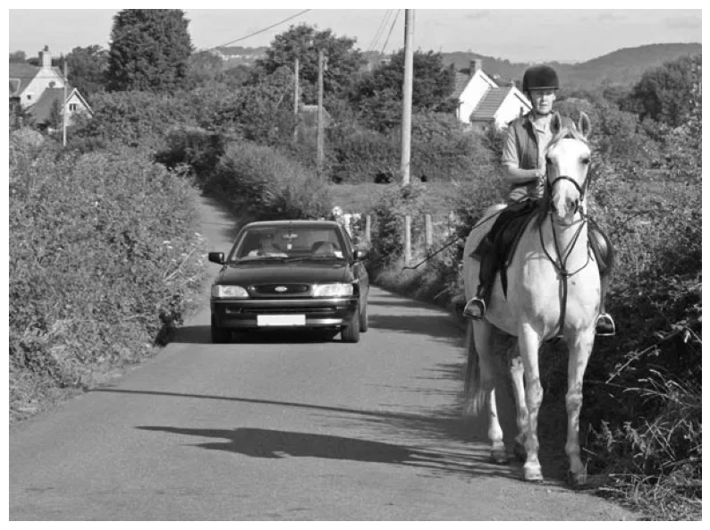

```python
plt_show(image)
```

Run the function on loaded image

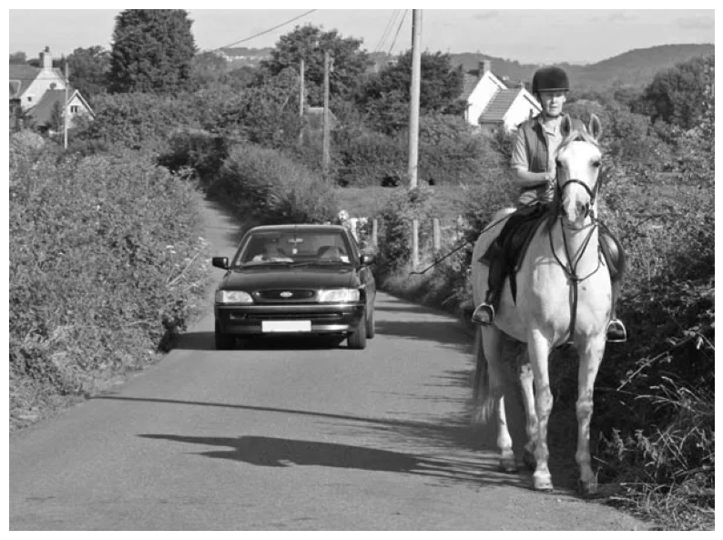

```
[[119 139 222 222]]
```

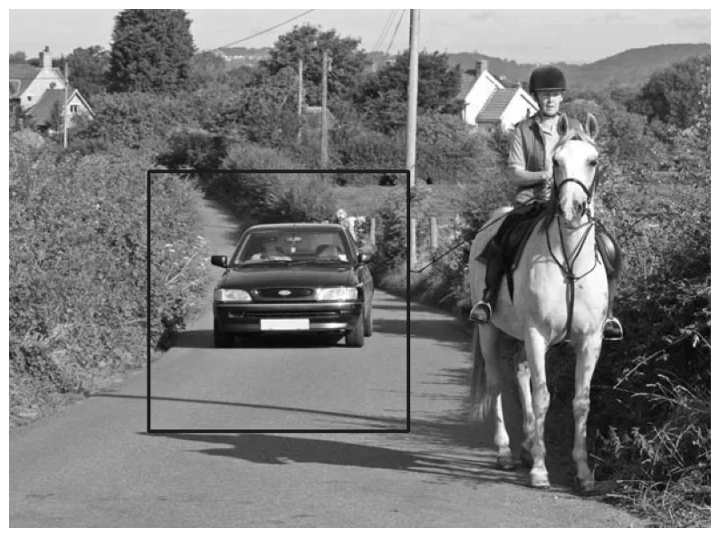

```python
detect_obj(image)
```

# Practice Exercise - Upload your image

Upload your image and see if your car will be correctly detected.

```python
## replace "your_uploaded_file" with your file name
my_image = cv2.imread("another_car.jpeg")
```

Run the Cascade classifier on your model to detect the object. How did it do?

[figure not shown]

```
[[ 714  244   39   39]
 [1091  428   74   74]
 [ 813  204   97   97]]
```

[figure not shown]

```python
detect_obj(my_image)
```

## Authors' rights

Machine Learning with Python course by IBM on Coursera: https://www.coursera.org/learn/machine-learning-with-python/

Completed and modified by Mathilde Marie Duville as part of the IBM Artificial Intelligence Engineering Professional Certificate and corresponding IBM badges. Please, follow the subsequent links to confirm the accreditation:

https://www.coursera.org/account/accomplishments/professional-cert/KSLW773DAATP?utm_source=link&utm_medium=certificate&utm_content=cert_image&utm_campaign=sharing_cta&utm_product=prof

https://www.credly.com/users/mathilde-marie-duville/badges

Author: [Aije Egwaikhide](https://www.linkedin.com/in/aije-egwaikhide/?utm_medium=Exinfluencer&utm_source=Exinfluencer&utm_content=000026UJ&utm_term=10006555&utm_id=NA-SkillsNetwork-Channel-cvstudio-2021-01-01) is a Data Scientist at IBM who holds a degree in Economics and Statistics from the University of Manitoba and a Post-grad in Business Analytics from St. Lawrence College, Kingston. She is currently pursuing her Masters in Management Analytics at Queens University. She is part of the IBM Developer Skills Network group where she brings her real-world experience to the courses she creates.

[Nayef Abou Tayoun](https://www.linkedin.com/in/nayefaboutayoun/?utm_medium=Exinfluencer&utm_source=Exinfluencer&utm_content=000026UJ&utm_term=10006555&utm_id=NA-SkillsNetwork-Channel-cvstudio-2021-01-01) is a Cognitive Data Scientist at IBM, and pursuing a Master's degree in Artificial intelligence

## Change Log

| Date (YYYY-MM-DD) | Version | Changed By | Change Description |
| --- | --- | --- | --- |
| 2021-04-09 | 1.0 | Aije | Updated to new template |
| 2021-03-02 | 0.2 | Aije | Updated code and instructions and added practice exercise |
| 2020-08-18 | 0.1 | Nayef | Created original version of the lab |

Copyright © 2021 IBM Corporation. All rights reserved.